# Menangani Autokorelasi

Gemala Aleida Fitri G1401231070

2025-08-29

```r
library(lmtest)
library(readxl)
library(TTR)
library(forecast)
library(orcutt) #untuk membuat model regresi Cochrane-Orcutt
library(HoRM)
data <- read_excel("C:/Users/Ainul Hayati/Documents/kuliah/Departemen/Semester 5/Metode Peramalan Deret Waktu/data/ipm pandeglang.xlsx")
data
```

```
## # A tibble: 15 × 2
##    Tahun   IPM
##    <dbl> <dbl>
##  1  2010  59.1
##  2  2011  59.9
##  3  2012  60.5
##  4  2013  61.4
##  5  2014  62.1
##  6  2015  62.7
##  7  2016  63.4
##  8  2017  63.8
##  9  2018  64.3
## 10  2019  64.9
## 11  2020  65
## 12  2021  65.2
## 13  2022  65.8
## 14  2023  66.4
## 15  2024  67.0
```

## Eksplorasi Data

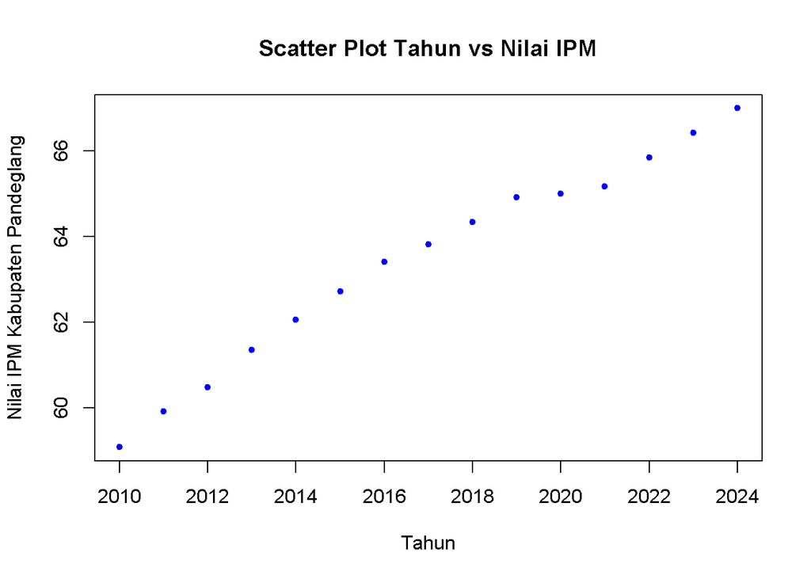

```r
#Eksplorasi Data
#Pembuatan Scatter Plot
tahun <- data$Tahun
ipm <- data$IPM
plot(tahun,ipm, pch = 20, col = "blue",
     main = "Scatter Plot Tahun vs Nilai IPM",
     xlab = "Tahun",
     ylab = "Nilai IPM Kabupaten Pandeglang")
```

```r
cor(tahun,ipm)
```

```
## [1] 0.9893826
```

Berdasarkan grafik scatter plot, terlihat adanya korelasi positif antara peubah tahun dengan nilai IPM, terlihat titik-titik pada plot yang naik ke arah kanan atas. Dari hasil perhitungandidapatkan nilai korelasi sebesar 0.9893826.

```r
model <- lm(IPM~Tahun, data=data)
summary(model)
```

```
##
## Call:
## lm(formula = IPM ~ Tahun, data = data)
##
## Residuals:
##     Min      1Q  Median      3Q     Max
## -0.5886 -0.2733 -0.0468  0.3656  0.5045
##
## Coefficients:
##               Estimate Std. Error t value Pr(>|t|)
## (Intercept) -1.021e+03  4.420e+01  -23.11 6.09e-12 ***
## Tahun        5.378e-01  2.191e-02   24.55 2.83e-12 ***
## ---
## Signif. codes:  0 '***' 0.001 '**' 0.01 '*' 0.05 '.' 0.1 ' ' 1
##
## Residual standard error: 0.3666 on 13 degrees of freedom
## Multiple R-squared:  0.9789, Adjusted R-squared:  0.9773
## F-statistic: 602.5 on 1 and 13 DF,  p-value: 2.828e-12
```

Model yang dihasilkan adalah
$$ipm = -1021 + 0.5378tahun$$
Berdasarkan ringkasan model dapat diketahui bahwa hasil uji F memiliki p-value < 0.05. Artinya, minimal terdapat satu variabel yang berpengaruh nyata terhadap model. Hasil uji-t parsial kedua parameter regresi, yaitu intersep dan koefisien regresi juga menunjukkan hal yang sama, yaitu memiliki p-value < 0.05 sehingga nyata dalam taraf 5%. Selanjutnya dapat dilihat juga nilai R2=0.9789. Artinya, sebesar 97.89% keragaman nilai IPM dapat dijelaskan oleh peubah tahun.

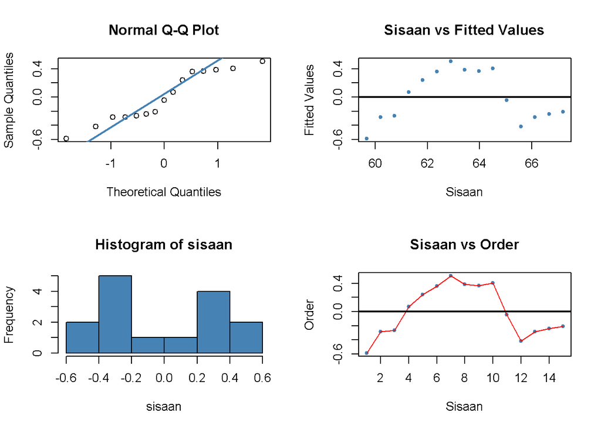

```r
#sisaan dan fitted value
sisaan<- residuals(model)
fitValue<- predict(model)

#Diagnostik dengan eksploratif
par(mfrow = c(2,2))
qqnorm(sisaan)
qqline(sisaan, col = "steelblue", lwd = 2)
plot(fitValue, sisaan, col = "steelblue", pch = 20, xlab = "Sisaan", ylab = "Fitted Values", main = "Sisaan vs Fitted Values")
abline(a = 0, b = 0, lwd = 2)
hist(sisaan, col = "steelblue")
plot(seq(1,15,1), sisaan, col = "steelblue", pch = 20, xlab = "Sisaan", ylab = "Order", main = "Sisaan vs Order")
lines(seq(1,15,1), sisaan, col = "red")
abline(a = 0, b = 0, lwd = 2)
```

```r
#Melihat Sisaan Menyebar Normal/Tidak
#H0: sisaan mengikuti sebaran normal
#H1: sisaan tidak mengikuti sebaran normal
shapiro.test(sisaan)
```

```
##
##  Shapiro-Wilk normality test
##
## data:  sisaan
## W = 0.91132, p-value = 0.1418
```

```r
ks.test(sisaan, "pnorm", mean=mean(sisaan), sd=sd(sisaan))
```

```
##
##  Exact one-sample Kolmogorov-Smirnov test
##
## data:  sisaan
## D = 0.18872, p-value = 0.5944
## alternative hypothesis: two-sided
```

Berdasarkan uji formal Saphiro-Wilk dan Kolmogorov-Smirnov didapatkan nilai p-value > 0.05. Artinya, cukup bukti untuk menyatakan sisaan berdistribusi normal.

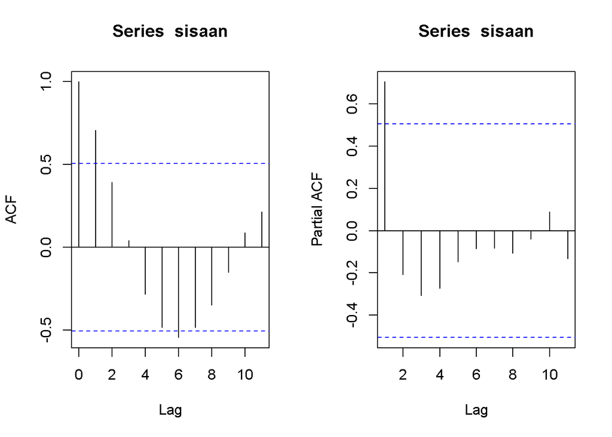

```r
#ACF dan PACF identifikasi autokorelasi
par(mfrow = c(1,2))
acf(sisaan)
pacf(sisaan)
```

Berdasarkan plot ACF dan PACF, terlihat ada lag yang melewati batas. Artinya, terdapat autokorelasi.

```r
#Deteksi autokorelasi dengan uji-Durbin Watson
#H0: tidak ada autokorelasi
#H1: ada autokorelasi
dwtest(model)
```

```
##
##  Durbin-Watson test
##
## data:  model
## DW = 0.36524, p-value = 6.771e-07
## alternative hypothesis: true autocorrelation is greater than 0
```

## Model Cochrane-Orcutt

```r
#Penanganan Autokorelasi Cochrane-Orcutt
#Mencari rho berdasarkan iterasi sampai konvergen
modelCO<-cochrane.orcutt(model)
modelCO
```

```
## Cochrane-orcutt estimation for first order autocorrelation
##
## Call:
## lm(formula = IPM ~ Tahun, data = data)
##
##  number of interaction: 51
##  rho 0.742457
##
## Durbin-Watson statistic
## (original):    0.36524 , p-value: 6.771e-07
## (transformed): 1.65979 , p-value: 1.589e-01
##
##  coefficients:
## (Intercept)       Tahun
## -829.057374    0.442703
```

Hasil keluaran model setelah dilakukan penanganan adalah sebagai berikut.
$$ipm=−829.057374+0.442703tahun$$
Hasil juga menunjukkan bahwa nilai DW dan p-value meningkat menjadi 1.65979 dan 0.1589. Nilai DW sudah berada pada rentang DU < DW < 4-DU atau 1.4357<DW<2.5643. Hal tersebut juga didukung dengan nilai p-value > 0.05, artinya belum cukup bukti menyatakan bahwa sisaan terdapat autokorelasi pada taraf nyata 5%. Untuk nilai ρ̂ optimum yang digunakan adalah 0.742457.

```r
#Rho optimum
rho<- modelCO$rho
rho
```

```
## [1] 0.7424565
```

```r
ipm[-1]
```

```
##  [1] 59.92 60.48 61.35 62.06 62.72 63.40 63.82 64.34 64.91 65.00 65.17 65.84
## [13] 66.42 66.99
```

```r
#Transformasi Manual
ipm.trans<- ipm[-1]-ipm[-12]*rho
tahun.trans<- tahun[-1]-tahun[-12]*rho
modelCOmanual<- lm(ipm.trans~tahun.trans)
summary(modelCOmanual)
```

```
##
## Call:
## lm(formula = ipm.trans ~ tahun.trans)
##
## Residuals:
##      Min       1Q   Median       3Q      Max
## -0.25240 -0.06795  0.05038  0.09882  0.18553
##
## Coefficients:
##               Estimate Std. Error t value Pr(>|t|)
## (Intercept) -188.24032   26.09892  -7.213 1.07e-05 ***
## tahun.trans    0.39406    0.05017   7.854 4.54e-06 ***
## ---
## Signif. codes:  0 '***' 0.001 '**' 0.01 '*' 0.05 '.' 0.1 ' ' 1
##
## Residual standard error: 0.1593 on 12 degrees of freedom
## Multiple R-squared:  0.8371, Adjusted R-squared:  0.8236
## F-statistic: 61.69 on 1 and 12 DF,  p-value: 4.538e-06
```

```r
b0bintang <- modelCOmanual$coefficients[-2]
b0 <- b0bintang/(1-rho)
b1 <- modelCOmanual$coefficients[-1]
b0
```

```
## (Intercept)
##   -730.9069
```

```r
b1
```

```
## tahun.trans
##   0.3940583
```

## Model Hildreth-Lu

```r
#Penanganan Autokorelasi Hildreth lu
# Hildreth-Lu
hildreth.lu.func<- function(r, model){
  x <- model.matrix(model)[,-1]
  y <- model.response(model.frame(model))
  n <- length(y)
  t <- 2:n
  y <- y[t]-r*y[t-1]
  x <- x[t]-r*x[t-1]

  return(lm(y~x))
}

#Pencariab rho yang meminimumkan SSE
r <- c(seq(0.1,0.9, by= 0.1))
tab <- data.frame("rho" = r, "SSE" = sapply(r, function(i){deviance(hildreth.lu.func(i, model))}))
round(tab, 4)
```

```
##   rho    SSE
## 1 0.1 1.0567
## 2 0.2 0.8563
## 3 0.3 0.6898
## 4 0.4 0.5572
## 5 0.5 0.4583
## 6 0.6 0.3932
## 7 0.7 0.3619
## 8 0.8 0.3645
## 9 0.9 0.4009
```

Pada hasil di atas terlihat ρ minimum ketika 0.7. Namun, hasil tersebut masih kurang teliti sehingga akan dicari kembali ρ yang lebih optimum dengan ketelitian yang lebih.

```r
#Rho optimal di sekitar 0.4
rOpt <- seq(0.6,0.9, by= 0.001)
tabOpt <- data.frame("rho" = rOpt, "SSE" = sapply(rOpt, function(i){deviance(hildreth.lu.func(i, model))}))
head(tabOpt[order(tabOpt$SSE),])
```

```
##       rho       SSE
## 143 0.742 0.3588955
## 144 0.743 0.3588956
## 142 0.741 0.3588987
## 145 0.744 0.3588991
## 141 0.740 0.3589053
## 146 0.745 0.3589061
```

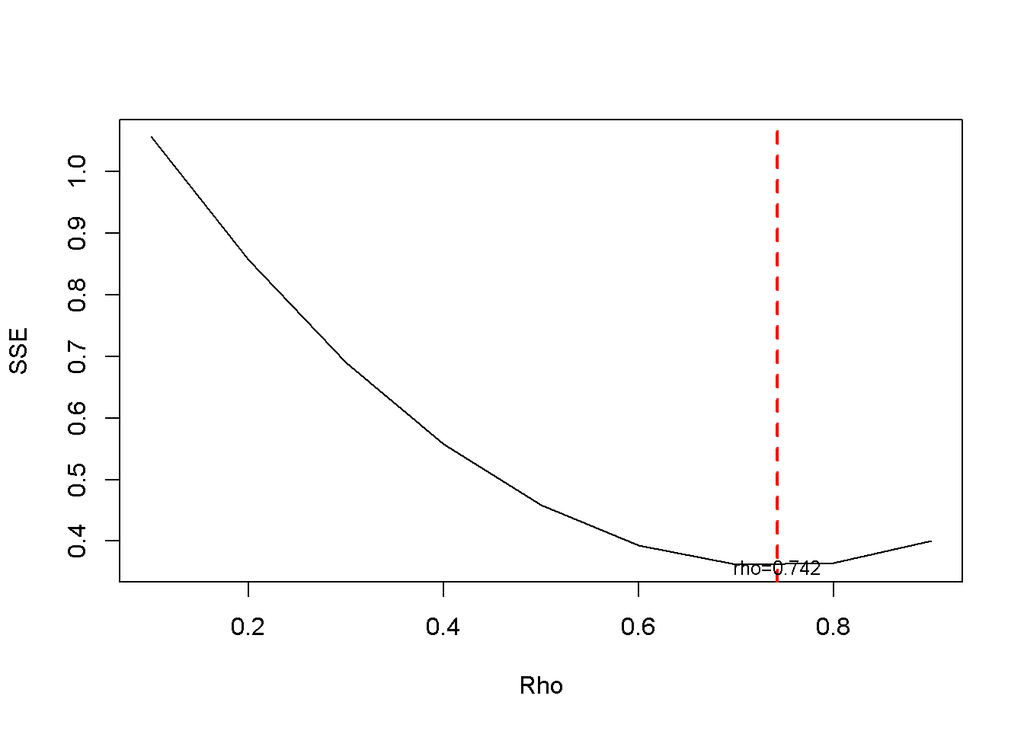

```r
#Grafik SSE optimum
par(mfrow = c(1,1))
plot(tab$SSE ~ tab$rho , type = "l", xlab = "Rho", ylab = "SSE")
abline(v = tabOpt[tabOpt$SSE==min(tabOpt$SSE),"rho"], lty = 2, col="red",lwd=2)
text(x=0.742, y=0.3588955, labels = "rho=0.742", cex = 0.8)
```

Perhitungan yang dilakukan aplikasi R menunjukkan bahwa nilai ρ optimum, yaitu saat SSE terkecil terdapat pada nilai ρ=0.742.

```r
#Model terbaik
modelHL <- hildreth.lu.func(0.742, model)
summary(modelHL)
```

```
##
## Call:
## lm(formula = y ~ x)
##
## Residuals:
##      Min       1Q   Median       3Q      Max
## -0.32518 -0.03766  0.07299  0.10291  0.16790
##
## Coefficients:
##               Estimate Std. Error t value Pr(>|t|)
## (Intercept) -213.99107   23.16518  -9.238 8.38e-07 ***
## x              0.44288    0.04444   9.966 3.72e-07 ***
## ---
## Signif. codes:  0 '***' 0.001 '**' 0.01 '*' 0.05 '.' 0.1 ' ' 1
##
## Residual standard error: 0.1729 on 12 degrees of freedom
## Multiple R-squared:  0.8922, Adjusted R-squared:  0.8832
## F-statistic: 99.31 on 1 and 12 DF,  p-value: 3.717e-07
```

```r
#Transformasi Balik
cat("y = ", coef(modelHL)[1]/(1-0.742), "+", coef(modelHL)[2],"x", sep = "")
```

```
## y = -829.4228+0.4428839x
```

Setelah dilakukan tranformasi balik, didapatkan model dengan metode Hildreth-Lu sebagai berikut.
$$ipm = -829.4228+0.4428839tahun$$

```r
#Deteksi autokorelasi
dwtest(modelHL)
```

```
##
##  Durbin-Watson test
##
## data:  modelHL
## DW = 1.6591, p-value = 0.1586
## alternative hypothesis: true autocorrelation is greater than 0
```

Hasil uji Durbin-Watson juga menunjukkan bawah nilai DW sebesar 1.6591 berada pada selang daerah tidak ada autokorelasi, yaitu pada rentang DU < DW < 4-DU atau 1.4357<DW<2.5643. Hal tersebut juga didukung oleh p-value sebesar 0.1586, di mana p-value > 0.05. Artinya tak tolak H0 atau belum cukup bukti menyatakan bahwa ada autokorelasi dalam data nilai IPM dengan metode Hildreth-Lu pada taraf nyata 5%.

```r
#Perbandingan
sseModelawal <- anova(model)$`Sum Sq`[-1]
sseModelCO <- anova(modelCOmanual)$`Sum Sq`[-1]
sseModelHL <- anova(modelHL)$`Sum Sq`[-1]
mseModelawal <- sseModelawal/length(ipm)
mseModelCO <- sseModelCO/length(ipm)
mseModelHL <- sseModelHL/length(ipm)
akurasi <- matrix(c(sseModelawal,sseModelCO,sseModelHL,
                    mseModelawal,mseModelCO,mseModelHL),nrow=2,ncol=3,byrow = T)
colnames(akurasi) <- c("Model Awal", "Model Cochrane-Orcutt", "Model Hildreth-Lu")
row.names(akurasi) <- c("SSE","MSE")
akurasi
```

```
##     Model Awal Model Cochrane-Orcutt Model Hildreth-Lu
## SSE   1.747604            0.30446762        0.35889547
## MSE   0.116507            0.02029784        0.02392636
```

Berdasarkan hasil tersebut dapat diketahui bahwa hasil penanganan autokorelasi dengan metode Cochrane-Orcutt memiliki SSE yang lebih kecil dibandingkan dengan Hildreth-Lu, yaitu sebesar 0.30446762 dan lebih baik dibandingkan model awal ketika autokorelasi masih terjadi, yaitu sebesar 1.747604.